# Marginal effects from categorical predictors

This walks through generating average marginal effects on the response scale for models with categorical predictors using `tidybayes::add_fitted_draws`. The example here uses `rstanarm`, but should work with minimal modification on `brms` as well.

Note: I am relatively new to average marginal effects, so this is partially my attempt to explain them and partially my attempt to better understand them myself. If there is anything here that looks off to you, please file an issue or a pull request.

## Setup

```r
library(tidyverse)
library(magrittr)
library(ggplot2)
library(rstan)
library(rstanarm)
library(modelr)
library(tidybayes)
library(ggstance)
library(patchwork)
library(latex2exp)

theme_set(theme_light() + theme(
  panel.border = element_blank()
))
rstan_options(auto_write = TRUE)
options(mc.cores = parallel::detectCores())
```

## Data

```r
set.seed(12345)
a1_prob = .3
a2_prob = .7
k = 40

df = bind_rows(
  data_frame(A = "a1", B = "b1", y = rbinom(k, 1, a1_prob) == 1),
  data_frame(A = "a2", B = "b1", y = rbinom(k, 1, a2_prob) == 1),
  data_frame(A = "a1", B = "b2", y = rbinom(k, 1, a1_prob + .1) == 1),
  data_frame(A = "a2", B = "b2", y = rbinom(k, 1, a2_prob + .1) == 1)
)
```

### Data plot

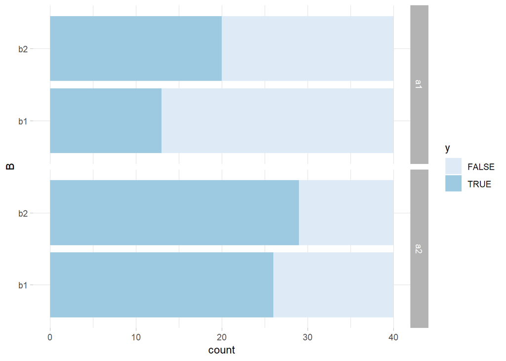

```r
df %>%
  ggplot(aes(y = B, fill = y)) +
  geom_barh() +
  facet_grid(A ~ .) +
  scale_fill_brewer()
```

## Model

```r
m = stan_glm(y ~ A*B, data = df, family = binomial)
```

```r
summary(m)
```

```
##
## Model Info:
##
##  function:     stan_glm
##  family:       binomial [logit]
##  formula:      y ~ A * B
##  algorithm:    sampling
##  priors:       see help('prior_summary')
##  sample:       4000 (posterior sample size)
##  observations: 160
##  predictors:   4
##
## Estimates:
##                 mean   sd     2.5%   25%    50%    75%    97.5%
## (Intercept)     -0.7    0.3   -1.4   -0.9   -0.7   -0.5   -0.1
## Aa2              1.3    0.5    0.4    1.0    1.3    1.6    2.2
## Bb2              0.7    0.5   -0.2    0.4    0.7    1.0    1.6
## Aa2:Bb2         -0.3    0.7   -1.6   -0.7   -0.3    0.1    1.0
## mean_PPD         0.6    0.1    0.4    0.5    0.6    0.6    0.6
## log-posterior -110.6    1.4 -114.2 -111.3 -110.2 -109.5 -108.8
##
## Diagnostics:
##               mcse Rhat n_eff
## (Intercept)   0.0  1.0  2043
## Aa2           0.0  1.0  2037
## Bb2           0.0  1.0  2010
## Aa2:Bb2       0.0  1.0  1913
## mean_PPD      0.0  1.0  3106
## log-posterior 0.0  1.0  1643
##
## For each parameter, mcse is Monte Carlo standard error, n_eff is a crude measure of effective sample size, and Rhat is the potential scale reduction factor on split chains (at convergence Rhat=1).
```

## Marginal effects at particular/“representative” values (“MER” marginal effects)

Let’s say we want to know the marginal mean conditional on particular values of our predictors. This is essentially what `add_fitted_draws`/`posterior_linpred` give us.

For example, the model above is something like this:

$$\begin{align}
y | A, B &\sim \textrm{Bernoulli}(q | A, B)\\
q | A, B &= g_p(A, B)
\end{align}$$

Each observation is drawn from a Bernoulli distribution, and the probability of an observation being `TRUE` is equal to $q$, which is a function of $A$ and $B$. For simplicity, we’ve just let that be some function $g_p(A, B)$. If we want to get particular about it, that function for the above model is something like this:

$$\begin{align}
q | A, B &= g_p(A, B)\\
&= \textrm{logit}^{-1}(\alpha + \beta_A[A = a_2] + \beta_B[B = b_2] + \beta_{AB}[A = a_2][B=b_2])
\end{align}$$

But the actual function $g_p$ **doesn’t really matter for our purposes**, so long as there’s something that can calculate it for us. What we want to know the expected value of $y$, which is the same thing as the probability $q$:

$$\begin{align}
\textrm{E}[y | A, B] &= q | A, B
\end{align}$$

Put another way, what proportion of observations in the population do we expect to be equal to `TRUE` for each combination of values of $A$ and $B$?

Fortunately, `add_fitted_draws` gives us the posterior distribution for exactly this quantity:

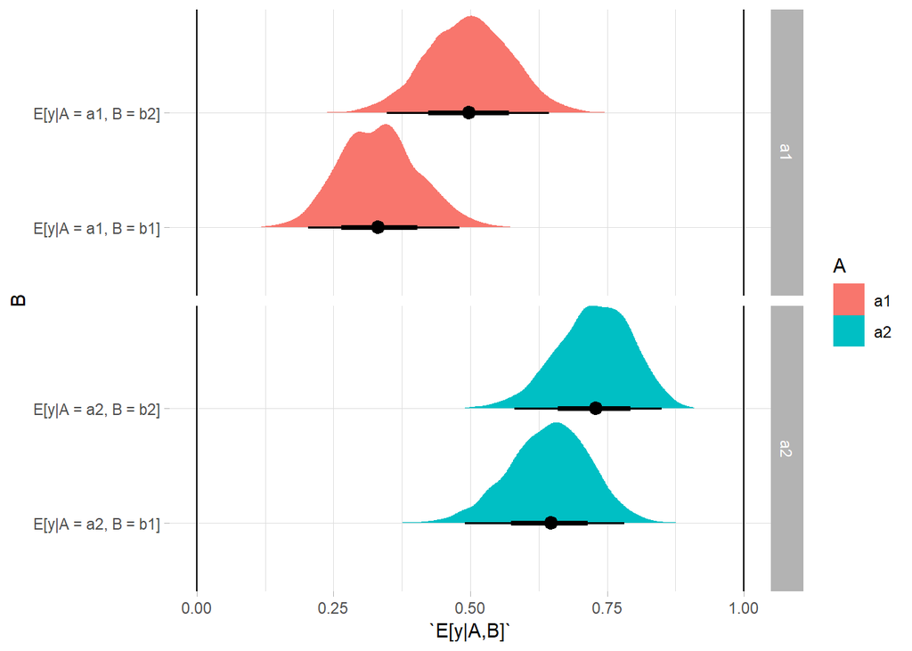

```r
AB_plot = df %>%
  data_grid(A, B) %>%
  # `value` just changes the column name in the output, not what any of the results are.
  # I've set to "E[y|A,B]" to make the correspondence to the math clear as this gets more
  # complicated as we go along
  add_fitted_draws(m, value = "E[y|A,B]") %>%
  ggplot(aes(y = paste0("E[y|A = ", A, ", B = ", B, "]"), x = `E[y|A,B]`, fill = A)) +
  geom_halfeyeh() +
  facet_grid(A ~ ., scales = "free") +
  xlim(0, 1) +
  ylab("B") +
  geom_vline(xintercept = c(0, 1))

AB_plot
```

## Average marginal effects (“AME”)

But let’s say we wanted to get the average effect for each value of $A$, marginalizing over $B$. So we want:

$$\begin{align}
\textrm{E}[y | A]
\end{align}$$

Our model can’t give us that directly. But we can use the [law of total expectation](https://en.wikipedia.org/wiki/Law_of_total_expectation) to express this expectation in terms of things we *can* get our model to give us:

$$\begin{align}
&E[y | A] &=& &\sum_{b \in \mathcal{B}}&\textrm{E}[y | A, B = b] \Pr[B = b]\\
&&=&&& \textrm{E}[y | A, B = b_1] \Pr[B = b_1] +\\&&&&& \textrm{E}[y | A, B = b_2] \Pr[B = b_2]
\end{align}$$

Two of these quantities are given to us by `fitted_draws`: $\textrm{E}[y | A, B = b_1]$ and $\textrm{E}[y | A, B = b_2]$.

However, we still need $\Pr[B = b_1]$ and $\Pr[B = b_2]$ to generate a marginal effect. These probabilities must come from somewhere else: maybe our experimental design, or maybe the population we’re interested in. For now, we’ll assume $\Pr[B = b_1] = \Pr[B = b_2] = 0.5$, i.e. $b_1$ and $b_2$ are equally likely in the population. Then we have:

$$\begin{align}
&E[y | A] &=&&& \textrm{E}[y | A, B = b_1] \Pr[B = b_1] +\\&&&&& \textrm{E}[y | A, B = b_2] \Pr[B = b_2]\\
&&=&&& \textrm{E}[y | A, B = b_1] \cdot 0.5 +\\&&&&& \textrm{E}[y | A, B = b_2] \cdot 0.5
\end{align}$$

Or equivalently, when we assume that all levels of some categorical variable we want to marginalize out are equally likely, then we can use an unweighted mean to marginalize it out:

$$\begin{align}
&E[y | A] &=&& {1 \over |\mathcal{B}|} \sum_{b \in \mathcal{B}}\textrm{E}[y | A, B = b]
\end{align}$$

**It is very important to stress** that this depends on a population made up of equal proportions of all possible values of $B$ being a meaningful thing to talk about.

Given the above, we can take the following steps to get the marginalized version:

1. Condition on all values of categorical variables (using `modelr::data_grid`)
2. Get draws from the distribution for the expected value of the response conditional on those variables (using `tidybayes::add_fitted_draws`)
3. Group by every predictor we don’t want to marginalize out + the `.draw` column (so we average within draws)
4. Marginalize out the categorical variables we don’t care about by averaging over them (`dplyr::summarise` + `mean`, or `dplyr::summarise` + `weighted.mean` if you have non-equal proportions for your population)

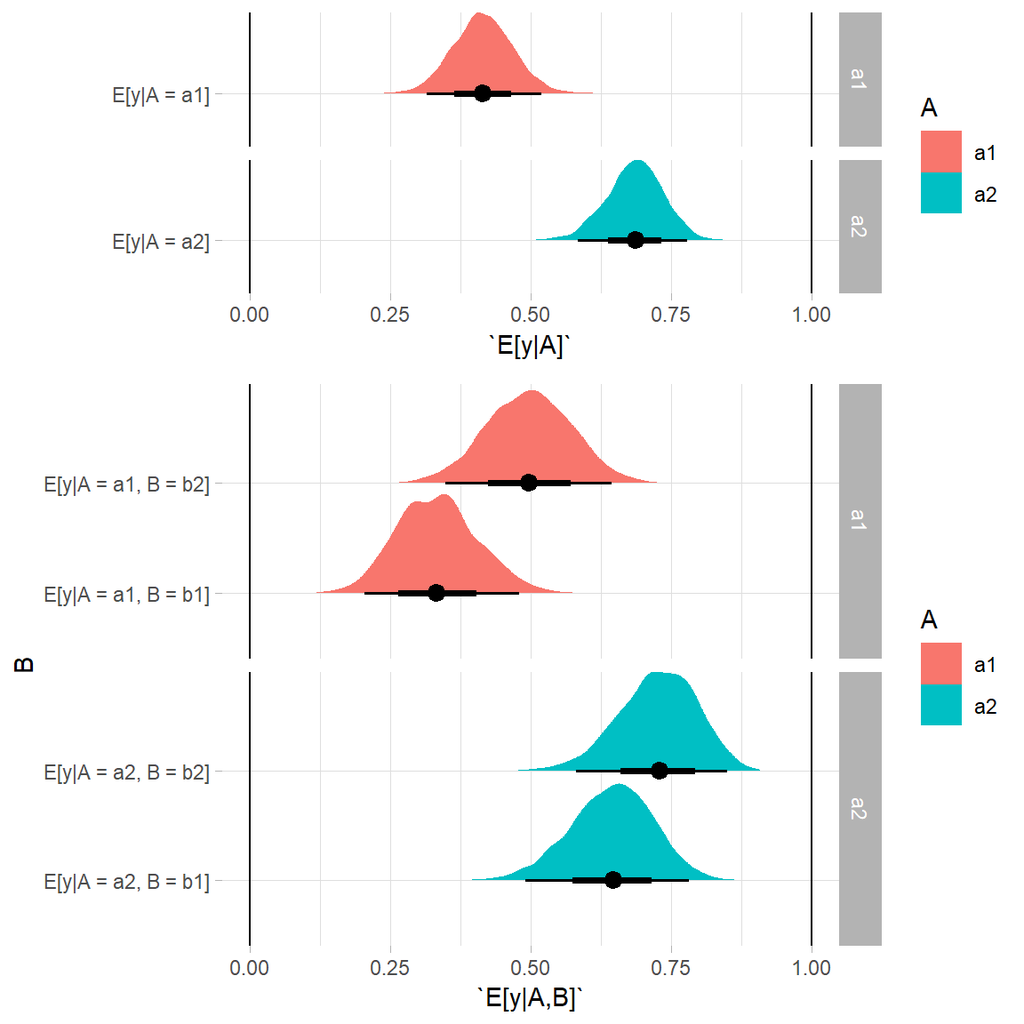

```r
A_plot = df %>%
  data_grid(A, B) %>%                          # condition on everything
  add_fitted_draws(m, value = "E[y|A,B]") %>%  # get conditional expectations
  group_by(A, .draw) %>%                       # group by predictors to keep
  summarise(`E[y|A]` = mean(`E[y|A,B]`)) %>%   # marginalize out other predictors
  ggplot(aes(y = paste0("E[y|A = ", A, "]"), x = `E[y|A]`, fill = A)) +
  geom_halfeyeh() +
  xlim(0, 1) +
  facet_grid(A ~ ., scale = "free") +
  ylab(NULL) +
  geom_vline(xintercept = c(0, 1))

A_plot / AB_plot +
  plot_layout(heights = c(1, 2))
```

You should be able to see how the marginalized effects in the top plot are the averages of the corresponding distributions in the lower plot.

If all went well, these marginalized effects should line up well with the observed proportions in the data (since they had equal numbers of observations per condition and we haven’t used any strong priors):

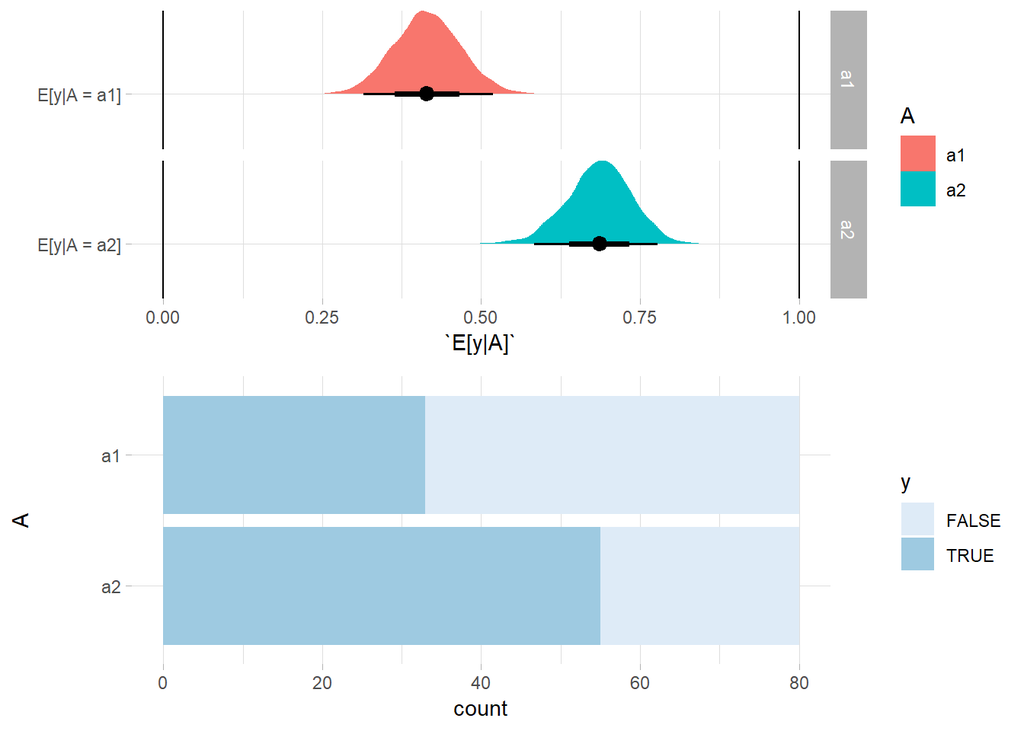

```r
marginal_data_plot = df %>%
  ggplot(aes(y = fct_rev(A), fill = y)) +
  geom_barh() +
  scale_fill_brewer() +
  ylab("A")

A_plot / marginal_data_plot
```

### Versus a model without B

Because there are an equal number of observations in every group in this dataset, these estimate line up with what we would get if we just omitted B from the model altogether:

```r
m2 = stan_glm(y ~ A, data = df, family = binomial)
```

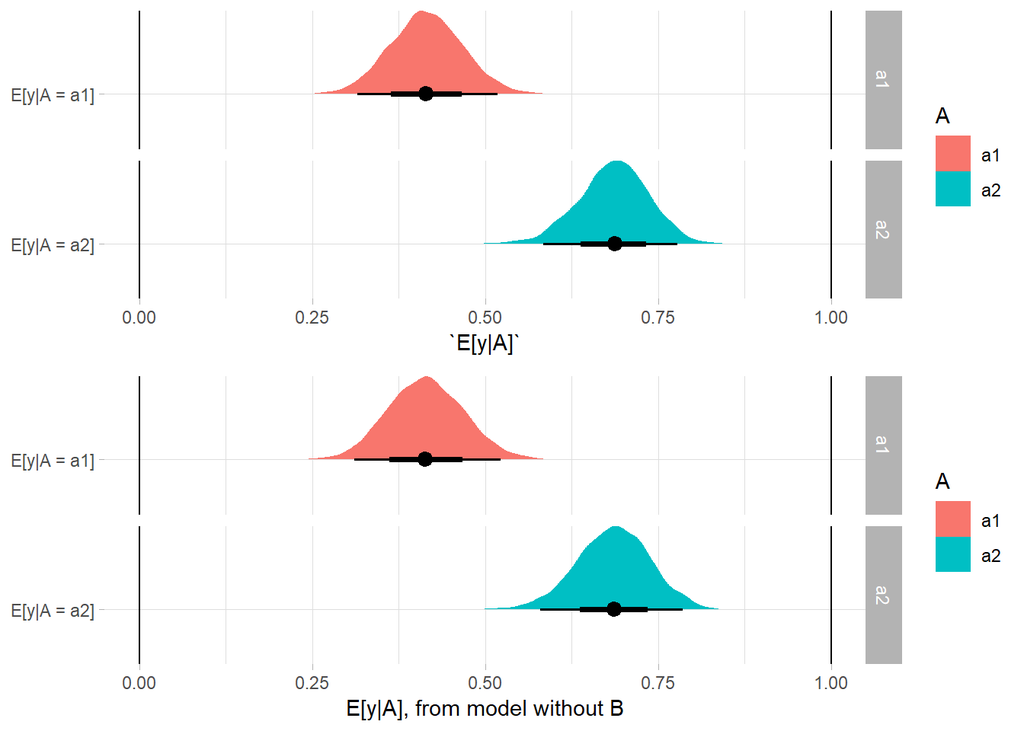

```r
A_plot_2 = df %>%
  data_grid(A) %>%                            # condition on everything
  add_fitted_draws(m2, value = "E[y|A]") %>%  # get conditional expectations
  ggplot(aes(y = paste0("E[y|A = ", A, "]"), x = `E[y|A]`, fill = A)) +
  geom_halfeyeh() +
  xlim(0, 1) +
  facet_grid(A ~ ., scale = "free") +
  ylab(NULL) +
  xlab("E[y|A], from model without B") +
  geom_vline(xintercept = c(0, 1))

A_plot / A_plot_2
```

This would not be the case if we had unequal cell sizes.

### Differences in AMEs

Given $\textrm{E}[y | A = a_1]$ and $\textrm{E}[y | A = a_2]$ as before:

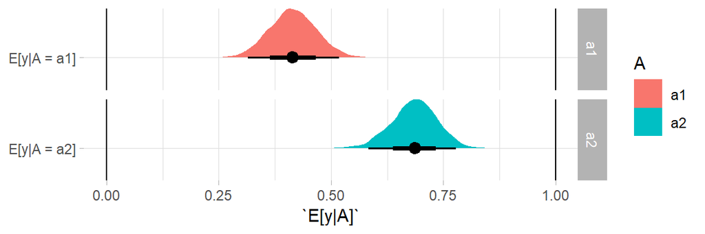

```r
A_plot
```

We might want to derive the posterior distribution for the difference in these means:

$$\textrm{E}[y | A = a_2] - \textrm{E}[y | A = a_1]$$

Since we can generate draws from the distributions for both quantities, we can use `tidybayes::compare_levels` to compute this difference (this will simply subtract the draws from pairwise combinations of sets of draws, according to the levels of some factor; in this case, `A`):

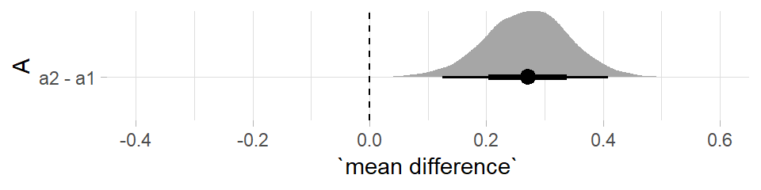

```r
# this part is the same as before
marginal_effects = df %>%
  data_grid(A, B) %>%                          # condition on everything
  add_fitted_draws(m, value = "E[y|A,B]") %>%  # get conditional expectations
  group_by(A, .draw) %>%                       # group by predictors to keep
  summarise(`E[y|A]` = mean(`E[y|A,B]`))       # marginalize out other predictors


# we can use compare_levels to calculate the mean difference
mean_diffs = marginal_effects %>%
  compare_levels(`E[y|A]`, by = A) %>%         # pairwise differences in `E[y|A]`, by levels of A
  rename(`mean difference` = `E[y|A]`)         # give this column a more accurate name

mean_diffs %>%
  ggplot(aes(x = `mean difference`, y = A)) +
  geom_halfeyeh() +
  geom_vline(xintercept = 0, linetype = "dashed") +
  xlim(-.4, .6)
```

And here’s a fancy version of this plot, aligned with the marginal estimates:

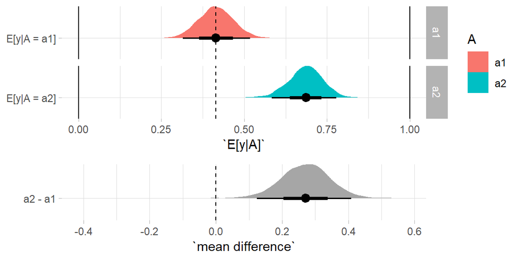

```r
# this is just so we can align the plot axes below
median_a1 = marginal_effects %>%
  filter(A == "a1") %$%
  median(`E[y|A]`)

A_plot_diff = mean_diffs %>%
  ggplot(aes(y = A, x = `mean difference`)) +
  geom_halfeyeh() +
  ylab(NULL) +
  geom_vline(xintercept = c(0, 1), linetype = "dashed") +
  coord_cartesian(xlim = c(-median_a1, 1 - median_a1))

(A_plot + geom_vline(xintercept = median_a1, linetype = "dashed")) /
  A_plot_diff +
  plot_layout(heights = c(2, 1))
```